# Week4PredictionAssignment

Xia Wenwen

05/04/2022

## Executive Summary

The goal of your project is to predict the manner in which they did the exercise. This is the “classe” variable in the training set. You may use any of the other variables to predict with. You should create a report describing how you built your model, how you used cross validation, what you think the expected out of sample error is, and why you made the choices you did. You will also use your prediction model to predict 20 different test cases.

```r
library(caret)
library(gbm)
library(randomForest)
library(corrplot)
library(RColorBrewer)
set.seed(3000)

training_dat = read.csv("pml-training.csv")
testing_dat = read.csv("pml-testing.csv")
```

## Feature Extraction and Data Prepration

Select sensor-related raw variables as predictors. There are totally 4 groups of variables:  
1. Belt-related variables  
2. Arm-related variables  
3. Dumbell-related variables  
4. Forearm-related variables

```r
belt_group <- c("roll_belt", "pitch_belt", "yaw_belt", "gyros_belt_x", "gyros_belt_y",
                "gyros_belt_z", "accel_belt_x", "accel_belt_y", "accel_belt_z",
                "magnet_belt_x", "magnet_belt_y", "magnet_belt_z")

arm_group <- c("roll_arm", "pitch_arm", "yaw_arm", "gyros_arm_x", "gyros_arm_y",
               "gyros_arm_z", "accel_arm_x", "accel_arm_y", "accel_arm_z",
               "magnet_arm_x", "magnet_arm_y", "magnet_arm_z")

dumbell_group <- c("roll_dumbbell", "pitch_dumbbell", "yaw_dumbbell", "gyros_dumbbell_x",
                   "gyros_dumbbell_y", "gyros_dumbbell_z", "accel_dumbbell_x", "accel_dumbbell_y",
                   "accel_dumbbell_z", "magnet_dumbbell_x", "magnet_dumbbell_y", "magnet_dumbbell_z")

forearm_group <- c("roll_forearm", "pitch_forearm", "yaw_forearm", "gyros_forearm_x",
                   "gyros_forearm_y", "gyros_forearm_z", "accel_forearm_x", "accel_forearm_y",
                   "accel_forearm_z", "magnet_forearm_x", "magnet_forearm_y", "magnet_forearm_z")

outcome <- c("classe")

training_set <- subset(training_dat, select = c(belt_group, arm_group,
                                                dumbell_group, forearm_group, outcome))
testing_set <- subset(testing_dat, select = c(belt_group, arm_group,
                                              dumbell_group, forearm_group))
```

Evaluate the correlations of the variables with respect to “classe”.

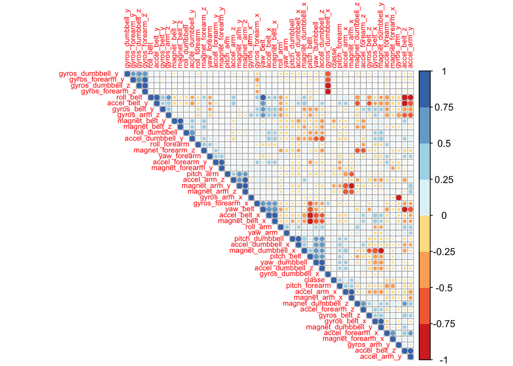

```r
training_eva <- training_set
training_eva$classe <- as.numeric(as.factor(training_eva$classe))
M <-cor(training_eva)
corrplot(M, type="upper", order="hclust", tl.cex = 0.6,
         col=brewer.pal(n=8, name="RdYlBu"))
```

Focus on rows and colomns with “classe”, we can find the positive and negative correlations between the other variable and “classe”.

Prepare the training and testing data with 0.75 ratio.

```r
inTrain = createDataPartition(training_set$classe, p = 3/4)[[1]]
training = training_set[ inTrain,]
testing = training_set[-inTrain,]
dim(training)
```

```
## [1] 14718    49
```

```r
dim(testing)
```

```
## [1] 4904   49
```

## Build Model with Cross Validation

Create 10 folds for cross validation in train control.

```r
train_control<- trainControl(method="cv", number=10, savePredictions = TRUE)
```

Choose the random forest model, and train the data with ntree = 10. The number of 10 trees is a proper number to balance the performance and accuracy.

```r
rf.model <- train(classe ~ .,data=training,  trControl=train_control, method="rf", prox=FALSE, ntree=10)
print(rf.model)
```

```
## Random Forest
##
## 14718 samples
##    48 predictor
##     5 classes: 'A', 'B', 'C', 'D', 'E'
##
## No pre-processing
## Resampling: Cross-Validated (10 fold)
## Summary of sample sizes: 13246, 13247, 13247, 13244, 13245, 13248, ...
## Resampling results across tuning parameters:
##
##   mtry  Accuracy   Kappa
##    2    0.9803653  0.9751543
##   25    0.9866849  0.9831562
##   48    0.9791434  0.9736176
##
## Accuracy was used to select the optimal model using the largest value.
## The final value used for the model was mtry = 25.
```

Evaluate the random forest model with training data, and get the in-sample error.

```r
rf.model.train.pred <- predict(rf.model, training)
train_cm <- confusionMatrix(as.factor(rf.model.train.pred), as.factor(training$classe))
print(train_cm)
```

```
## Confusion Matrix and Statistics
##
##           Reference
## Prediction    A    B    C    D    E
##          A 4183    1    0    0    0
##          B    2 2847    0    0    0
##          C    0    0 2567    4    0
##          D    0    0    0 2408    1
##          E    0    0    0    0 2705
##
## Overall Statistics
##
##                Accuracy : 0.9995
##                  95% CI : (0.9989, 0.9998)
##     No Information Rate : 0.2843
##     P-Value [Acc > NIR] : < 2.2e-16
##
##                   Kappa : 0.9993
##
##  Mcnemar's Test P-Value : NA
##
## Statistics by Class:
##
##                      Class: A Class: B Class: C Class: D Class: E
## Sensitivity            0.9995   0.9996   1.0000   0.9983   0.9996
## Specificity            0.9999   0.9998   0.9997   0.9999   1.0000
## Pos Pred Value         0.9998   0.9993   0.9984   0.9996   1.0000
## Neg Pred Value         0.9998   0.9999   1.0000   0.9997   0.9999
## Prevalence             0.2843   0.1935   0.1744   0.1639   0.1839
## Detection Rate         0.2842   0.1934   0.1744   0.1636   0.1838
## Detection Prevalence   0.2843   0.1936   0.1747   0.1637   0.1838
## Balanced Accuracy      0.9997   0.9997   0.9998   0.9991   0.9998
```

```r
train_accuracy <- train_cm$overall[[1]]
print(train_accuracy)
```

```
## [1] 0.9994564
```

```r
in_sample_err <- 1- train_accuracy
print(in_sample_err)
```

```
## [1] 0.0005435521
```

Evaluate the random forest model with testing data, and get the out-of-sample error.

```r
rf.model.test.pred <- predict(rf.model, testing)
test_cm <- confusionMatrix(as.factor(rf.model.test.pred), as.factor(testing$classe))
print(test_cm)
```

```
## Confusion Matrix and Statistics
##
##           Reference
## Prediction    A    B    C    D    E
##          A 1392    3    0    0    1
##          B    1  938    7    1    2
##          C    2    8  844   13    4
##          D    0    0    4  789    9
##          E    0    0    0    1  885
##
## Overall Statistics
##
##                Accuracy : 0.9886
##                  95% CI : (0.9852, 0.9914)
##     No Information Rate : 0.2845
##     P-Value [Acc > NIR] : < 2.2e-16
##
##                   Kappa : 0.9856
##
##  Mcnemar's Test P-Value : NA
##
## Statistics by Class:
##
##                      Class: A Class: B Class: C Class: D Class: E
## Sensitivity            0.9978   0.9884   0.9871   0.9813   0.9822
## Specificity            0.9989   0.9972   0.9933   0.9968   0.9998
## Pos Pred Value         0.9971   0.9884   0.9690   0.9838   0.9989
## Neg Pred Value         0.9991   0.9972   0.9973   0.9963   0.9960
## Prevalence             0.2845   0.1935   0.1743   0.1639   0.1837
## Detection Rate         0.2838   0.1913   0.1721   0.1609   0.1805
## Detection Prevalence   0.2847   0.1935   0.1776   0.1635   0.1807
## Balanced Accuracy      0.9984   0.9928   0.9902   0.9891   0.9910
```

```r
test_accuracy <- test_cm$overall[[1]]
print(test_accuracy)
```

```
## [1] 0.9885808
```

```r
out_of_sample_err <- 1- test_accuracy
print(out_of_sample_err)
```

```
## [1] 0.01141925
```

The out-of-sample error is 0.0114192, which is larger than in-sample error 5.4355211^{-4} due to the over-fitting of random forest model.

Random forest is one of the most used/accurate algorithms along with boosting. It is extremely important to use cross validation when running random forest algorithms.

## Predict 20 different test cases

Use the 20 test cases to get the predicated classes.

```r
test.case.pred <- predict(rf.model, testing_set)
print(test.case.pred)
```

```
##  [1] B A B A A E D B A A B C B A E E A B B B
## Levels: A B C D E
```